# Explore Polysaccharide Binding

Many of the TanOak genes coming up with high dN/dS in the polysaccharide binding category are LRK10L2 homologs. The goal here is to align the TanOak paralogs with other related orthologs, build a tree, and see where changes are happening.

```r
library(tidyverse)
library(Biostrings)
library(UpSetR)
library(gplots)
```

## Sequence retrieval

Start with blastp of `../output/polysaccharide_peps.fa`

Try blastp against the nr_clustered(experimental) database

(but maybe I should be doing tblastx or tblastn so that I can get DNA sequences when I retrieve…)

rename the sequence files (only needs to be done once)

```r
tanoak_poly_aa <- readAAStringSet("../output/polysaccharide_peps.fa")
rename_tibble <- tibble(qname = str_c(names(tanoak_poly_aa), ".fa"),
                        filename = c("seqdump.txt", str_c("seqdump (",1:9,").txt")))
rename_tibble

path <- "../output/polysaccharide_seq_downloads/blastp/"

rename_tibble %>% mutate(test=walk2(filename, qname, ~ file.rename(file.path(path, .x), file.path(path, .y))))
```

## Sequence overlap

Have common sequences been retrieved for the different queries?

```r
hittable <- read_csv("../output/polysaccharide_seq_downloads/blastp/B7WS0BG6013-Alignment-HitTable.csv",
                     col_names = c("query", "target")) %>%
  mutate(query = str_remove(query, "_p.*"))
head(hittable)
```

| query | target | X3 | X4 | X5 | X6 | X7 | X8 | X9 | X10 | X11 | X12 | X13 |
| --- | --- | --- | --- | --- | --- | --- | --- | --- | --- | --- | --- | --- |
| augustus_masked-585 | XP_023925741.1 | 60.507 | 276 | 82 | 8 | 1 | 259 | 9 | 274 | 3.51e-102 | 309 | 73.19 |
| augustus_masked-585 | XP_023916374.1 | 58.271 | 266 | 99 | 6 | 1 | 257 | 1 | 263 | 9.72e-94 | 286 | 72.18 |
| augustus_masked-585 | XP_023881247.1 | 56.877 | 269 | 104 | 6 | 1 | 260 | 1 | 266 | 8.13e-87 | 280 | 71.00 |
| augustus_masked-585 | XP_023916359.1 | 59.783 | 276 | 91 | 10 | 1 | 261 | 1 | 271 | 2.38e-86 | 280 | 71.38 |
| augustus_masked-585 | KAF3965141.1 | 57.778 | 270 | 101 | 8 | 1 | 261 | 1 | 266 | 2.75e-86 | 267 | 69.63 |
| augustus_masked-585 | XP_030954726.1 | 57.993 | 269 | 89 | 10 | 1 | 254 | 1 | 260 | 4.16e-86 | 279 | 68.40 |

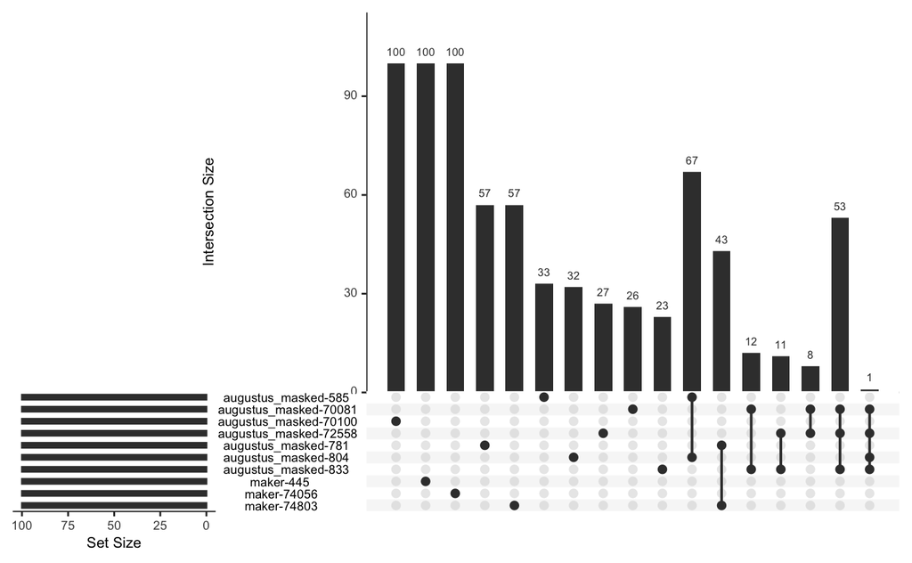

```r
hit.counts <- hittable %>% select(target, query) %>%
  unique() %>%
  table() %>%
  as.data.frame.matrix()

upset(hit.counts, nsets = 10, nintersects = NA)
```

70100 (Wall-associated receptor kinase galacturonan-binding; Wall-associated receptor kinase C-terminal; LRK10L3),  
445 (Wall-associated receptor kinase galacturonan-binding; Wall-associated receptor kinase C-terminal); NA, and  
74056 (NA; ATL96) are unique

585 (NA; LRK10L2) and  
804 (Wall-associated receptor kinase galacturonan-binding; ATL21) can be grouped together

781 (EGF-like domain profile.; Wall-associated receptor kinase galacturonan-binding; Serine/Threonine protein kinases active-site signature.; Protein kinase domain; Wall-associated kinase; EGF_CA; Protein kinase domain profile. ;WAK5 ) AND  
74803 (Calcium-binding EGF-like domain signature.; EGF-like domain profile.; Wall-associated receptor kinase galacturonan-binding; Calcium-binding EGF domain; EGF_CA; EGF-like domain signature 2.; Aspartic acid and asparagine hydroxylation site.; WAK2 ) can be grouped together

70081 (NA; ATL21),  
72558 (Wall-associated receptor kinase galacturonan-binding; ATL21), and  
833 (Wall-associated receptor kinase galacturonan-binding; ATL21) can be grouped together

Doesn’t make a ton of sense. what if blast these queries against one another

## Blast all to all (polysaccharide queries)

```r
cd ../output
makeblastdb -in polysaccharide_peps.fa -dbtype prot
```

```r
cd ../output
blastp -query polysaccharide_peps.fa -db polysaccharide_peps.fa -outfmt 7 > polysaccharide_self_blast.tsv
```

```r
headers <- readLines("../output/polysaccharide_self_blast.tsv", n = 4)
headers <- headers[4] # only keep the 4th line

headers <- headers %>%
  str_remove("# Fields: ") %>% # get rid of the extraneous information
  str_split(", ") %>% #split into pieces
  unlist() %>% #convert to vector
  make.names() %>% #make names the R can understand
  str_replace(fixed(".."), ".") %>% # get rid of double .. in names.
  str_replace("X.identity", "pct.identity") %>% # "%" got replaced with X, we can do better.
  str_remove(fixed(".acc.ver"))

poly_self_blast <- read_tsv("../output/polysaccharide_self_blast.tsv", col_names=headers, comment="#") %>%
  mutate(query = str_extract(query, "[0-9]+"),
         subject = str_extract(subject, "[0-9]+"))
head(poly_self_blast)
```

| query | subject | pct.identity | alignment.length | mismatches | gap.opens | q.start | q.end | s.start | s.end | evalue | bit.score |
| --- | --- | --- | --- | --- | --- | --- | --- | --- | --- | --- | --- |
| 585 | 585 | 100.000 | 261 | 0 | 0 | 1 | 261 | 1 | 261 | 0.00e+00 | 543.0 |
| 585 | 804 | 52.817 | 284 | 102 | 11 | 1 | 258 | 1 | 278 | 1.77e-84 | 244.0 |
| 585 | 72558 | 42.647 | 68 | 35 | 4 | 33 | 96 | 37 | 104 | 6.62e-10 | 46.6 |
| 585 | 72558 | 62.500 | 8 | 3 | 0 | 53 | 60 | 104 | 111 | 2.60e+00 | 17.7 |
| 585 | 833 | 28.758 | 153 | 88 | 8 | 4 | 148 | 5 | 144 | 6.82e-10 | 47.0 |
| 585 | 70081 | 35.294 | 102 | 49 | 6 | 35 | 119 | 28 | 129 | 1.44e-09 | 46.2 |

Make matrix with bit score only

```r
poly.self.bits <- poly_self_blast %>% select(query, subject, bit.score) %>%
  group_by(query, subject) %>%
  slice_max(order_by = bit.score) %>%
  pivot_wider(names_from = subject, values_from = bit.score, values_fill = 0) %>%
  as.data.frame() %>%
  column_to_rownames("query") %>%
  as.matrix.data.frame()

poly.self.bits
```

[output not shown]

```r
colnames(poly.self.bits) == rownames(poly.self.bits)
```

```
 [1] TRUE TRUE TRUE TRUE TRUE TRUE TRUE TRUE TRUE TRUE
```

convert to distance

normalize per column

```r
poly.self.bits.norm <- apply(poly.self.bits, 2, function(x) x / max(x))
poly.self.bits.dist <- 1-poly.self.bits.norm
```

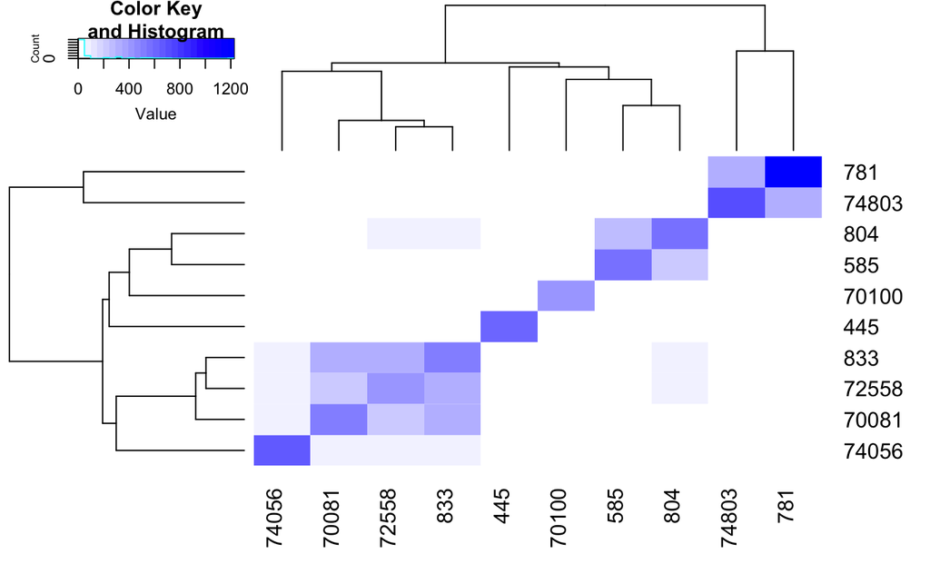

```r
cl <- hclust(dist(poly.self.bits))

heatmap.2(poly.self.bits, trace = "none", Colv = as.dendrogram(cl), Rowv=as.dendrogram(cl),
          col = colorpanel(25, low="white", high = "blue"))
```

## 804 and 585

Let’s start with 804 and 585. Need to get TanOak proteins, Oak proteins, and the blast results in one file. Then align and make tree.

write out the table

align!

```r
time mafft --thread 3 --localpair --maxiterate 1000 --reorder ../output/tanoak_804_805_orthos.fa > ../output/tanoak_804_805_orthos_aligned.fa
```